# [중간고사정리]데이터변형

### mutate 위치 바꾸기

#### before 이용해 위치 바꾸기

```r
flights %>%
    select(year:day,
           ends_with("delay"),
           distance,
           air_time) %>%
    mutate(gain = arr_delay - dep_delay,
           speed = distance / air_time*60,
           .before = 1) # 맨앞으로
```

```
## # A tibble: 336,776 × 9
##     gain speed  year month   day dep_delay arr_delay distance air_time
##    <dbl> <dbl> <int> <int> <int>     <dbl>     <dbl>    <dbl>    <dbl>
##  1     9  370.  2013     1     1         2        11     1400      227
##  2    16  374.  2013     1     1         4        20     1416      227
##  3    31  408.  2013     1     1         2        33     1089      160
##  4   -17  517.  2013     1     1        -1       -18     1576      183
##  5   -19  394.  2013     1     1        -6       -25      762      116
##  6    16  288.  2013     1     1        -4        12      719      150
##  7    24  404.  2013     1     1        -5        19     1065      158
##  8   -11  259.  2013     1     1        -3       -14      229       53
##  9    -5  405.  2013     1     1        -3        -8      944      140
## 10    10  319.  2013     1     1        -2         8      733      138
## # ℹ 336,766 more rows
```

#### after 이용해 위치 바꾸기

```r
flights %>%
    select(year:day,
           ends_with("delay"),
           distance,
           air_time) %>%
    mutate(gain = arr_delay - dep_delay,
           hours = air_time / 60,
           gain_per_hour = gain / hours,
           .after = day)
```

```
## # A tibble: 336,776 × 10
##     year month   day  gain hours gain_per_hour dep_delay arr_delay distance
##    <int> <int> <int> <dbl> <dbl>         <dbl>     <dbl>     <dbl>    <dbl>
##  1  2013     1     1     9 3.78           2.38         2        11     1400
##  2  2013     1     1    16 3.78           4.23         4        20     1416
##  3  2013     1     1    31 2.67          11.6          2        33     1089
##  4  2013     1     1   -17 3.05          -5.57        -1       -18     1576
##  5  2013     1     1   -19 1.93          -9.83        -6       -25      762
##  6  2013     1     1    16 2.5            6.4         -4        12      719
##  7  2013     1     1    24 2.63           9.11        -5        19     1065
##  8  2013     1     1   -11 0.883        -12.5         -3       -14      229
##  9  2013     1     1    -5 2.33          -2.14        -3        -8      944
## 10  2013     1     1    10 2.3            4.35        -2         8      733
## # ℹ 336,766 more rows
## # ℹ 1 more variable: air_time <dbl>
```

### 변수의 입력과 출력

#### .keep = “used” 사용

```r
flights %>%
    select(year:day,
           ends_with("delay"),
           distance,
           air_time) %>%
    mutate(gain = arr_delay - dep_delay,
           hours = air_time / 60,
           gain_per_hour = gain / hours,
           .keep = "used" )
```

```
## # A tibble: 336,776 × 6
##    dep_delay arr_delay air_time  gain hours gain_per_hour
##        <dbl>     <dbl>    <dbl> <dbl> <dbl>         <dbl>
##  1         2        11      227     9 3.78           2.38
##  2         4        20      227    16 3.78           4.23
##  3         2        33      160    31 2.67          11.6
##  4        -1       -18      183   -17 3.05          -5.57
##  5        -6       -25      116   -19 1.93          -9.83
##  6        -4        12      150    16 2.5            6.4
##  7        -5        19      158    24 2.63           9.11
##  8        -3       -14       53   -11 0.883        -12.5
##  9        -3        -8      140    -5 2.33          -2.14
## 10        -2         8      138    10 2.3            4.35
## # ℹ 336,766 more rows
```

select와 mutate에서 사용되지 않은 변수는 제외 #### transmute()이용해 새 변수만 남김

```r
transmute(
  flights,
  gain = dep_delay - arr_delay,
  hours = air_time / 60,
  gain_per_hour = gain / hours
)
```

```
## # A tibble: 336,776 × 3
##     gain hours gain_per_hour
##    <dbl> <dbl>         <dbl>
##  1    -9 3.78          -2.38
##  2   -16 3.78          -4.23
##  3   -31 2.67         -11.6
##  4    17 3.05           5.57
##  5    19 1.93           9.83
##  6   -16 2.5           -6.4
##  7   -24 2.63          -9.11
##  8    11 0.883         12.5
##  9     5 2.33           2.14
## 10   -10 2.3           -4.35
## # ℹ 336,766 more rows
```

### 유용한 생성함수

#### 모듈러 연산

```r
flights %>%
    transmute(dep_time,
              hour = dep_time%/%100,
              minute = dep_time%%100)
```

```
## # A tibble: 336,776 × 3
##    dep_time  hour minute
##       <int> <dbl>  <dbl>
##  1      517     5     17
##  2      533     5     33
##  3      542     5     42
##  4      544     5     44
##  5      554     5     54
##  6      554     5     54
##  7      555     5     55
##  8      557     5     57
##  9      557     5     57
## 10      558     5     58
## # ℹ 336,766 more rows
```

%/%은 몫, %%는 나머지-시간을 시와 분으로 분해할 수 있다. ### 오프셋 - 벡터를 당기거나 밀기

```r
x <- 1:10
lag(x)
```

```
##  [1] NA  1  2  3  4  5  6  7  8  9
```

벡터 x를 앞으로 1만큼 밀었다.

```r
x <- 1:10
lead(x)
```

```
##  [1]  2  3  4  5  6  7  8  9 10 NA
```

벡터 x를 압으로 1만큼 당겼다. ### 누적집계

```r
x<-1:10
```

```r
cumsum(x)
```

```
##  [1]  1  3  6 10 15 21 28 36 45 55
```

누적합

```r
cummean(x)
```

```
##  [1] 1.0 1.5 2.0 2.5 3.0 3.5 4.0 4.5 5.0 5.5
```

누적평균 ### 랭킹

```r
y <- c(1,2,2,NA,3,4)
rank(y)
```

```
## [1] 1.0 2.5 2.5 6.0 4.0 5.0
```

소수점 표시, 동일값 동일 랭크, NA: 가장 하위

```r
y <- c(1,2,2,NA,3,4)
min_rank(y)
```

```
## [1]  1  2  2 NA  4  5
```

정수, 동일값 동일 랭크, NA: NA

```r
y <- c(1,2,2,NA,3,4)
row_number(y)
```

```
## [1]  1  2  3 NA  4  5
```

정수, 동일값 다른 랭크(순서대로), NA: na

```r
y <- c(1,2,2,NA,3,4)
dense_rank(y)
```

```
## [1]  1  2  2 NA  3  4
```

정수, 동일값 하나로 취급, NA: na

```r
y <- c(1,2,2,NA,3,4)
percent_rank(y)
```

```
## [1] 0.00 0.25 0.25   NA 0.75 1.00
```

비율, 동일값 하나로 취급 , NA: na

```r
y <- c(1,2,2,NA,3,4)
cume_dist(y)
```

```
## [1] 0.2 0.6 0.6  NA 0.8 1.0
```

누적 비율, 동일값 같은 랭크, NA: na

```r
flights %>%
    select(dep_delay,arr_delay,carrier) %>%
    mutate(
        gain = dep_delay - arr_delay,
        rank = min_rank(desc(gain)),
    ) %>%
    arrange(desc(gain)) %>%
    head(10)
```

```
## # A tibble: 10 × 5
##    dep_delay arr_delay carrier  gain  rank
##        <dbl>     <dbl> <chr>   <dbl> <int>
##  1       235       126 EV        109     1
##  2        60       -27 HA         87     2
##  3       206       126 HA         80     3
##  4        17       -62 DL         79     4
##  5        24       -52 HA         76     5
##  6        48       -26 UA         74     6
##  7        34       -40 UA         74     6
##  8        31       -42 UA         73     8
##  9        -2       -75 UA         73     8
## 10         9       -63 DL         72    10
```

##### cars93 데이터프레임의 가격(Price)를 기준으로 정렬(ordering)이 된 상태에서 동일한 개수를 가진 4개의 sub group으로 나누기

- cars93 데이터

```r
library(MASS)
```

```r
Cars93[ ,c("Manufacturer", "Model", "Type", "Price")] %>%
  mutate(quartile = ntile(Price, 4))
```

```
##     Manufacturer          Model    Type Price quartile
## 1          Acura        Integra   Small  15.9        2
## 2          Acura         Legend Midsize  33.9        4
## 3           Audi             90 Compact  29.1        4
## 4           Audi            100 Midsize  37.7        4
## 5            BMW           535i Midsize  30.0        4
## 6          Buick        Century Midsize  15.7        2
## 7          Buick        LeSabre   Large  20.8        3
## 8          Buick     Roadmaster   Large  23.7        4
## 9          Buick        Riviera Midsize  26.3        4
## 10      Cadillac        DeVille   Large  34.7        4
## 11      Cadillac        Seville Midsize  40.1        4
## 12     Chevrolet       Cavalier Compact  13.4        2
## 13     Chevrolet        Corsica Compact  11.4        1
## 14     Chevrolet         Camaro  Sporty  15.1        2
```

[output cut: 79 more lines]

ntile을 사용하면 분위수로 나타낼 수 있다. ## 그룹화 요약

```
summarize() : 하나의 행으로 축약
na.rm =     : True: 결측치 제거후 연산
n()         : 개수 세기
```

### Laham 패키지 데이터

```r
library(Lahman)
batting <- as_tibble(Lahman::Batting)
batting
```

```
## # A tibble: 112,184 × 22
##    playerID  yearID stint teamID lgID      G    AB     R     H   X2B   X3B    HR
##    <chr>      <int> <int> <fct>  <fct> <int> <int> <int> <int> <int> <int> <int>
##  1 abercda01   1871     1 TRO    NA        1     4     0     0     0     0     0
##  2 addybo01    1871     1 RC1    NA       25   118    30    32     6     0     0
##  3 allisar01   1871     1 CL1    NA       29   137    28    40     4     5     0
##  4 allisdo01   1871     1 WS3    NA       27   133    28    44    10     2     2
##  5 ansonca01   1871     1 RC1    NA       25   120    29    39    11     3     0
##  6 armstbo01   1871     1 FW1    NA       12    49     9    11     2     1     0
##  7 barkeal01   1871     1 RC1    NA        1     4     0     1     0     0     0
##  8 barnero01   1871     1 BS1    NA       31   157    66    63    10     9     0
##  9 barrebi01   1871     1 FW1    NA        1     5     1     1     1     0     0
## 10 barrofr01   1871     1 BS1    NA       18    86    13    13     2     1     0
## # ℹ 112,174 more rows
## # ℹ 10 more variables: RBI <int>, SB <int>, CS <int>, BB <int>, SO <int>,
## #   IBB <int>, HBP <int>, SH <int>, SF <int>, GIDP <int>
```

```
playerID        : 플레이어 ID 코드
H               : 안타(Hits)
AB              : 유효타석수
타율(기술수준)  : H/AB
```

#### 기술 수준과 유효타석수 사이 상관관계보기

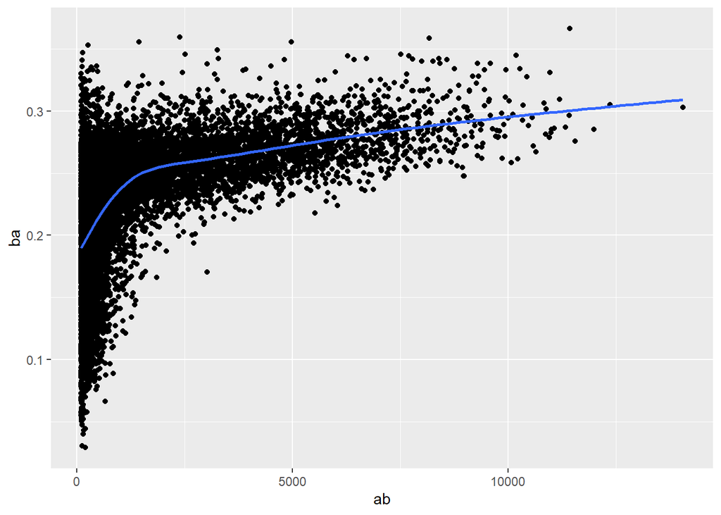

```r
batting %>% group_by(playerID) %>%
    summarise(ba= sum(H, na.rm=T)/sum(AB, na.rm = T),
              ab=sum(AB, na.rm = T)) %>%
    filter(ab>100) %>%
    ggplot(aes(ab,ba))+
    geom_point()+
    geom_smooth(se=F)
```

양의 상관관계를 보임 ### 유용한 함수

```
[위치측정값]
mean()      :평균
median()    :중앙값
---
[산포 측정값]
sd()        :표준편차
IQR()       :사분위범위위
mad()       :중위절대편차 E[|x_i-mu|]
---
[순위 측정값]
min()       :최소
quantile(, ):분위수
max()       :최대
```

#### mad 예

```r
dt1 <- c(1,2,3,4,5,6,7,8,9,10)
dt2 <- c(1,2,3,4,5,6,7,8,9,100)
```

```r
dt_dev <- c(mad(dt1),mad(dt2),
            sd(dt1), sd(dt2),
            IQR(dt1), IQR(dt2))
names(dt_dev) <- rep(c("dt1","dt2"),3)
```

[figure not shown]

[output not shown]

```r
barplot(dt_dev, beside=T,
        col=c("red","red","blue","blue","green","green"))
legend("topleft",
  legend = c("MAD", "sd", "IQR"), fill = c("red","blue","green"), cex=1.2
)
```

#### 각 날짜의 처음과 마지막 항공편 출발 시간

```r
flights %>%
    filter(!is.na(dep_time),!is.na(arr_time) ) %>%
    group_by(month, day) %>%
    summarise(fir_dep = first(dep_time),
              last_dep = last(dep_time))
```

```
## # A tibble: 365 × 4
## # Groups:   month [12]
##    month   day fir_dep last_dep
##    <int> <int>   <int>    <int>
##  1     1     1     517     2356
##  2     1     2      42     2354
##  3     1     3      32     2349
##  4     1     4      25     2358
##  5     1     5      14     2357
##  6     1     6      16     2355
##  7     1     7      49     2359
##  8     1     8     454     2351
##  9     1     9       2     2252
## 10     1    10       3     2320
## # ℹ 355 more rows
```

#### 항공기가 비행한 마일 수 카운트

```r
flights %>%
    filter(!is.na(dep_time),!is.na(arr_time)) %>%
    count(tailnum, wt=distance)
```

```
## # A tibble: 4,037 × 2
##    tailnum      n
##    <chr>    <dbl>
##  1 D942DN    3418
##  2 N0EGMQ  240626
##  3 N10156  110389
##  4 N102UW   25722
##  5 N103US   24619
##  6 N104UW   24616
##  7 N10575  140603
##  8 N105UW   23618
##  9 N107US   21677
## 10 N108UW   32070
## # ℹ 4,027 more rows
```

### 데이터 프레임을 다중변수로 그룹화 - 그룹해제

```
.groups = "drop"        :그룹 해제
.groups = "drop_last"   :마지막만 그룹 해제
.groups = "keep"        :그룹 유지
```

```r
daily <- flights %>%
    group_by(year, month, day)

daily %>%
    summarise(n=n())
```

```
## # A tibble: 365 × 4
## # Groups:   year, month [12]
##     year month   day     n
##    <int> <int> <int> <int>
##  1  2013     1     1   842
##  2  2013     1     2   943
##  3  2013     1     3   914
##  4  2013     1     4   915
##  5  2013     1     5   720
##  6  2013     1     6   832
##  7  2013     1     7   933
##  8  2013     1     8   899
##  9  2013     1     9   902
## 10  2013     1    10   932
## # ℹ 355 more rows
```

경고 메세지 뜬다.

```r
daily <- flights %>%
    group_by(year, month, day)

daily %>%
    summarise(n=n(),
              .groups = "drop_last")
```

```
## # A tibble: 365 × 4
## # Groups:   year, month [12]
##     year month   day     n
##    <int> <int> <int> <int>
##  1  2013     1     1   842
##  2  2013     1     2   943
##  3  2013     1     3   914
##  4  2013     1     4   915
##  5  2013     1     5   720
##  6  2013     1     6   832
##  7  2013     1     7   933
##  8  2013     1     8   899
##  9  2013     1     9   902
## 10  2013     1    10   932
## # ℹ 355 more rows
```

#### 최악의 지연연 찾기

```r
flights %>%
    group_by(year, month, day) %>%
    filter(rank(desc(arr_delay))<10)
```

```
## # A tibble: 3,306 × 19
## # Groups:   year, month, day [365]
##     year month   day dep_time sched_dep_time dep_delay arr_time sched_arr_time
##    <int> <int> <int>    <int>          <int>     <dbl>    <int>          <int>
##  1  2013     1     1      848           1835       853     1001           1950
##  2  2013     1     1     1815           1325       290     2120           1542
##  3  2013     1     1     1842           1422       260     1958           1535
##  4  2013     1     1     1942           1705       157     2124           1830
##  5  2013     1     1     2006           1630       216     2230           1848
##  6  2013     1     1     2115           1700       255     2330           1920
##  7  2013     1     1     2205           1720       285       46           2040
##  8  2013     1     1     2312           2000       192       21           2110
##  9  2013     1     1     2343           1724       379      314           1938
## 10  2013     1     2     1244            900       224     1431           1104
## # ℹ 3,296 more rows
## # ℹ 11 more variables: arr_delay <dbl>, carrier <chr>, flight <int>,
## #   tailnum <chr>, origin <chr>, dest <chr>, air_time <dbl>, distance <dbl>,
## #   hour <dbl>, minute <dbl>, time_hour <dttm>
```

#### 그룹별 척도를 위한 표준화

```r
# 기준값보다 큰 그룹 모두 찾기기
popular_dests <- flights %>%
  group_by(dest) %>%
  filter(n() > 365)
popular_dests
```

```
## # A tibble: 332,577 × 19
## # Groups:   dest [77]
##     year month   day dep_time sched_dep_time dep_delay arr_time sched_arr_time
##    <int> <int> <int>    <int>          <int>     <dbl>    <int>          <int>
##  1  2013     1     1      517            515         2      830            819
##  2  2013     1     1      533            529         4      850            830
##  3  2013     1     1      542            540         2      923            850
##  4  2013     1     1      544            545        -1     1004           1022
##  5  2013     1     1      554            600        -6      812            837
##  6  2013     1     1      554            558        -4      740            728
##  7  2013     1     1      555            600        -5      913            854
##  8  2013     1     1      557            600        -3      709            723
##  9  2013     1     1      557            600        -3      838            846
## 10  2013     1     1      558            600        -2      753            745
## # ℹ 332,567 more rows
## # ℹ 11 more variables: arr_delay <dbl>, carrier <chr>, flight <int>,
## #   tailnum <chr>, origin <chr>, dest <chr>, air_time <dbl>, distance <dbl>,
## #   hour <dbl>, minute <dbl>, time_hour <dttm>
```

```r
popular_dests %>%
    filter(arr_delay > 0) %>%
    mutate(prop_delay = arr_delay / sum(arr_delay))
```

```
## # A tibble: 131,106 × 20
## # Groups:   dest [77]
##     year month   day dep_time sched_dep_time dep_delay arr_time sched_arr_time
##    <int> <int> <int>    <int>          <int>     <dbl>    <int>          <int>
##  1  2013     1     1      517            515         2      830            819
##  2  2013     1     1      533            529         4      850            830
##  3  2013     1     1      542            540         2      923            850
##  4  2013     1     1      554            558        -4      740            728
##  5  2013     1     1      555            600        -5      913            854
##  6  2013     1     1      558            600        -2      753            745
##  7  2013     1     1      558            600        -2      924            917
##  8  2013     1     1      559            600        -1      941            910
##  9  2013     1     1      600            600         0      837            825
## 10  2013     1     1      602            605        -3      821            805
## # ℹ 131,096 more rows
## # ℹ 12 more variables: arr_delay <dbl>, carrier <chr>, flight <int>,
## #   tailnum <chr>, origin <chr>, dest <chr>, air_time <dbl>, distance <dbl>,
## #   hour <dbl>, minute <dbl>, time_hour <dttm>, prop_delay <dbl>
```